# 05 Prepare : Reading

## Objectives

- Bitwise operations.
- Image Blending with masks.
- Processing Videos and capturing the camera on laptops.

Most of the "reading" for this week is found on wikipedia and videos. Remember that you are required to go through all of this.

- https://pythonprogramming.net/image-arithmetics-logic-python-opencv-tutorial/
- https://en.wikipedia.org/wiki/Mask_(computing)
- https://www.learnopencv.com/seamless-cloning-using-opencv-python-cpp/

## Masking

This weeks topic is on blending images together. Below is an example of blending images "black" and "white" using a mask image.

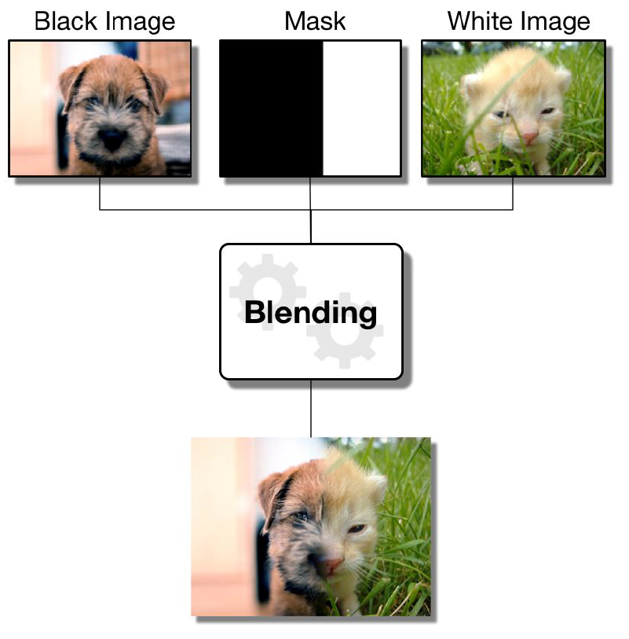

### Bitwise Operations

In this section, we will be introducing how to do bitwise operations on images. This is the AND, OR, XOR and NOT operations.

[Bitwise Operations](http://opencvexamples.blogspot.com/2013/10/bitwise-and-or-xor-and-not.html)

The following was taken from [Bitwise Operators](https://en.wikipedia.org/wiki/Bitwise_operation)

> **Bitwise operators**

> In the explanations below, any indication of a bit's position is counted from the right (least significant) side, advancing left. For example, the binary value 0001 (decimal 1) has zeroes at every position but the first one.

> **NOT**

> The bitwise NOT, or complement, is a unary operation that performs logical negation on each bit, forming the ones' complement of the given binary value. Bits that are 0 become 1, and those that are 1 become 0. For example:

> NOT 0111 (decimal 7) = 1000 (decimal 8) NOT 10101011 = 01010100 The bitwise complement is equal to the two's complement of the value minus one. If two's complement arithmetic is used, then NOT x = -x − 1.

> For unsigned integers, the bitwise complement of a number is the "mirror reflection" of the number across the half-way point of the unsigned integer's range. For example, for 8-bit unsigned integers, NOT x = 255 - x, which can be visualized on a graph as a downward line that effectively "flips" an increasing range from 0 to 255, to a decreasing range from 255 to 0. A simple but illustrative example use is to invert a grayscale image where each pixel is stored as an unsigned integer.

> **AND**

> A bitwise AND takes two equal-length binary representations and performs the logical AND operation on each pair of the corresponding bits, by multiplying them. Thus, if both bits in the compared position are 1, the bit in the resulting binary representation is 1 (1 × 1 = 1); otherwise, the result is 0 (1 × 0 = 0 and 0 × 0 = 0). For example:

> ```
> 0101 (decimal 5)
> ```

> AND 0011 (decimal 3) = 0001 (decimal 1) The operation may be used to determine whether a particular bit is set (1) or clear (0). For example, given a bit pattern 0011 (decimal 3), to determine whether the second bit is set we use a bitwise AND with a bit pattern containing 1 only in the second bit:

> ```
> 0011 (decimal 3)
> ```

> AND 0010 (decimal 2) = 0010 (decimal 2) Because the result 0010 is non-zero, we know the second bit in the original pattern was set. This is often called bit masking. (By analogy, the use of masking tape covers, or masks, portions that should not be altered or portions that are not of interest. In this case, the 0 values mask the bits that are not of interest.)

> The bitwise AND may be used to clear selected bits (or flags) of a register in which each bit represents an individual Boolean state. This technique is an efficient way to store a number of Boolean values using as little memory as possible.

> For example, 0110 (decimal 6) can be considered a set of four flags, where the first and fourth flags are clear (0), and the second and third flags are set (1). The second bit may be cleared by using a bitwise AND with the pattern that has a zero only in the second bit:

> ```
> 0110 (decimal 6)
> ```

> AND 1101 (decimal 13) = 0100 (decimal 4) Because of this property, it becomes easy to check the parity of a binary number by checking the value of the lowest valued bit. Using the example above:

> ```
> 0110 (decimal 6)
> ```

> AND 0001 (decimal 1) = 0000 (decimal 0) Because 6 AND 1 is zero, 6 is divisible by two and therefore even.

> **OR**

> A bitwise OR takes two bit patterns of equal length and performs the logical inclusive OR operation on each pair of corresponding bits. The result in each position is 0 if both bits are 0, while otherwise the result is 1. For example:

> 0101 (decimal 5) OR 0011 (decimal 3) = 0111 (decimal 7) The bitwise OR may be used to set to 1 the selected bits of the register described above. For example, the fourth bit of 0010 (decimal 2) may be set by performing a bitwise OR with the pattern with only the fourth bit set:

> 0010 (decimal 2) OR 1000 (decimal 8) = 1010 (decimal 10)

> **XOR**

> A bitwise XOR takes two bit patterns of equal length and performs the logical exclusive OR operation on each pair of corresponding bits. The result in each position is 1 if only the first bit is 1 or only the second bit is 1, but will be 0 if both are 0 or both are 1. In this we perform the comparison of two bits, being 1 if the two bits are different, and 0 if they are the same. For example:

> ```
> 0101 (decimal 5)
> ```

> XOR 0011 (decimal 3) = 0110 (decimal 6) The bitwise XOR may be used to invert selected bits in a register (also called toggle or flip). Any bit may be toggled by XORing it with 1. For example, given the bit pattern 0010 (decimal 2) the second and fourth bits may be toggled by a bitwise XOR with a bit pattern containing 1 in the second and fourth positions:

> ```
> 0010 (decimal 2)
> ```

> XOR 1010 (decimal 10) = 1000 (decimal 8) This technique may be used to manipulate bit patterns representing sets of Boolean states.

> Assembly language programmers sometimes use XOR as a short-cut to setting the value of a register to zero. Performing XOR on a value against itself always yields zero, and on many architectures this operation requires fewer clock cycles and memory than loading a zero value and saving it to the register.

### Applying a mask to an image

```
Original Images
```

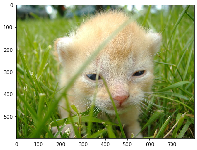

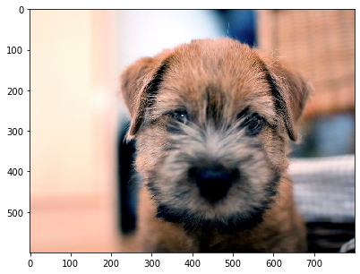

```
Mask Image
```

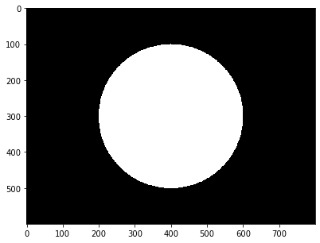

```
foreground Image
```

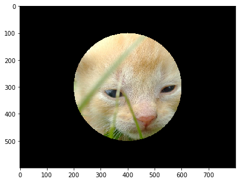

```
background Image
```

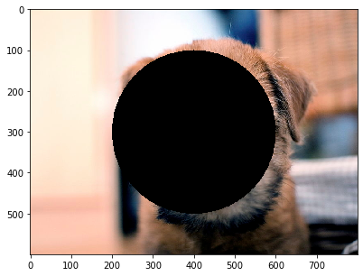

```
final Image
```

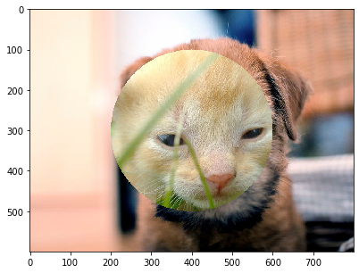

```python
%matplotlib inline
import numpy as np
import cv2
from matplotlib import pyplot as plt
plt.rcParams['figure.figsize'] = [10, 5]

image1 = cv2.imread('blend1.jpg')
image2 = cv2.imread('blend2.jpg')

print('Original Images')
plt.imshow(cv2.cvtColor(image1, cv2.COLOR_BGR2RGB))
plt.show()
plt.imshow(cv2.cvtColor(image2, cv2.COLOR_BGR2RGB))
plt.show()

# Create a mask for the temple (image 8 bit image)
rows, cols, _ = image1.shape
mask = np.zeros((rows, cols), dtype=np.uint8)
cv2.circle(mask, (cols // 2, rows // 2), 200, (255, 255, 255), -1)

print('Mask Image')
plt.imshow(cv2.cvtColor(mask, cv2.COLOR_BGR2RGB))
plt.show()

# foreground image from blend1 image
foreground = cv2.bitwise_or(image1, image1, mask = mask)
print('foreground Image')
plt.imshow(cv2.cvtColor(foreground, cv2.COLOR_BGR2RGB))
plt.show()

# must invert the mask for blend2 image
mask = cv2.bitwise_not(mask)
background = cv2.bitwise_or(image2, image2, mask = mask)
print('background Image')
plt.imshow(cv2.cvtColor(background, cv2.COLOR_BGR2RGB))
plt.show()

# OR fore and back ground images
final = cv2.bitwise_or(foreground, background)
print('final Image')
plt.imshow(cv2.cvtColor(final, cv2.COLOR_BGR2RGB))
plt.show()
```

## Video Processing

A video is a stream of frames. In OpenCV, these frames are numpy arrays.

#### Example: Read a video and display each frame to the screen

```
video = cv2.VideoCapture(filename)

# Check if camera opened successfully
if (video.isOpened() == False):
    print("Error opening video stream or file")

frame_width = int(video.get(cv2.CAP_PROP_FRAME_WIDTH))
frame_height = int(video.get(cv2.CAP_PROP_FRAME_HEIGHT))
frame_count = int(video.get(cv2.CAP_PROP_FRAME_COUNT))

fps = int(video.get(cv2.CAP_PROP_FPS))
print(frame_width, frame_height, frame_count, fps)

# Read until video is completed
while (video.isOpened()):
    # Capture frame-by-frame
    ret, frame = video.read()
    if ret == True:
        # Display the resulting frame
        cv2.imshow('Frame', frame)
        cv2.waitKey(1000 // fps)
    # Break the loop
    else:
        break

# When everything done, release the video capture object
video.release()
cv2.destroyAllWindows()
```

#### Example: Reading frames from the laptop camera

```
import numpy as np
import cv2

cap = cv2.VideoCapture(0)  # Notice the '0' instead of a filename

while(True):
    # Capture frame-by-frame
    ret, frame = cap.read()

    # Display the resulting frame
    cv2.imshow('frame', frame)

    if cv2.waitKey(1) & 0xFF == ord('q'):
        break

# When everything done, release the capture
cap.release()
cv2.destroyAllWindows()
```

#### Example: Reading a video, resizing frames and saving the new frames to a video file

```
video = cv2.VideoCapture(file)

# Check if camera opened successfully
if (video.isOpened() == False):
    print("Error opening video stream or file")

frame_width = int(video.get(cv2.CAP_PROP_FRAME_WIDTH))
frame_height = int(video.get(cv2.CAP_PROP_FRAME_HEIGHT))
frame_count = int(video.get(cv2.CAP_PROP_FRAME_COUNT))
fps = int(video.get(cv2.CAP_PROP_FPS))
print(frame_width, frame_height, frame_count, fps)

# Define the codec and create VideoWriter object.The output is stored in the dstfile MP4 file.
new_size = (frame_height // 2, frame_width // 2)
out = cv2.VideoWriter(dstfile, cv2.VideoWriter_fourcc(*'mp4v'), fps, new_size)

# Read until video is completed
while (video.isOpened()):
    # Capture frame-by-frame
    ret, frame = video.read()
    if ret == True:
        new_frame = cv2.resize(frame, new_size)
        out.write(new_frame)
    # Break the loop
    else:
        break

# When everything done, release the video capture object
video.release()
out.release()
```